# WILD7150 Lab 2 - Assumptions of Regression

Steven Cabrera

2022-08-31

## Dataset #1

For each 1 prey/ha increase in prey density, we observed a 0.41 prey killer per predator per day (± 0.19; ± 95% C.I.) increase in predation rate (p = 3.23e-05; r<sup>2</sup> = 0.11).

**Violates assumption of homoscedasticity**

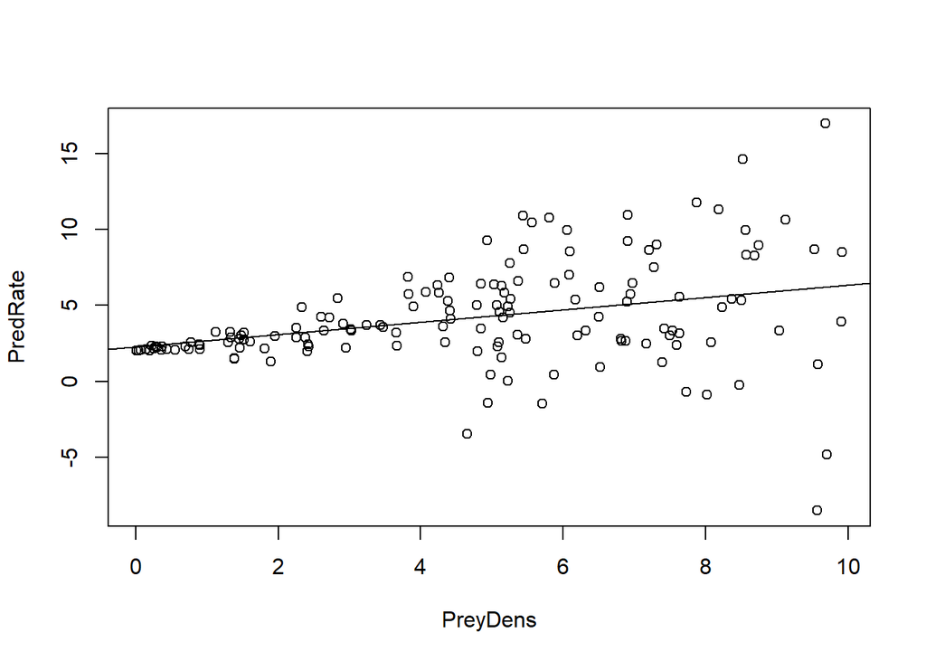

## Dataset #2

For each 1 year increase in stand age, we observed a 1.83 m2 (± 0.079; ± 95% C.I.) increase in basal area (p = <2e-16; r<sup>2</sup> = 0.97).

**Violates assumption of no autocorrelation**

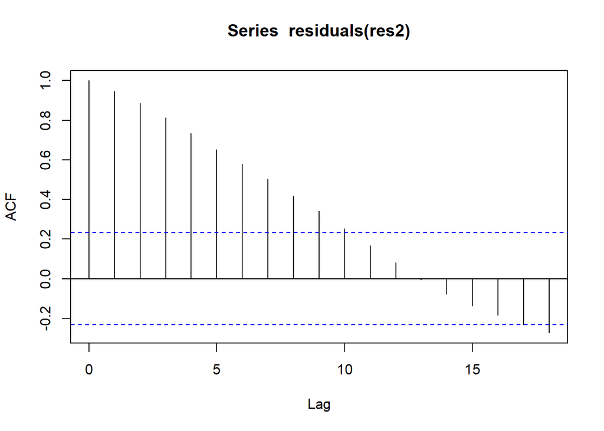

```
##
## Autocorrelations of series 'residuals(res2)', by lag
##
##      1      2      3      4      5      6      7      8      9     10     11
##  0.946  0.885  0.813  0.733  0.652  0.579  0.503  0.417  0.341  0.253  0.167
##     12     13     14     15     16     17     18     NA     NA     NA     NA
##  0.082 -0.006 -0.078 -0.136 -0.184 -0.232 -0.273     NA     NA     NA     NA
##     NA     NA     NA     NA     NA     NA     NA     NA     NA     NA     NA
##     NA     NA     NA     NA     NA     NA     NA     NA     NA     NA     NA
##     NA     NA     NA     NA     NA     NA     NA     NA     NA     NA     NA
##     NA     NA     NA     NA     NA     NA     NA     NA     NA     NA     NA
##     NA     NA     NA     NA     NA     NA     NA     NA     NA     NA     NA
##     NA     NA     NA     NA     NA     NA     NA     NA     NA     NA     NA
##     NA     NA     NA     NA     NA     NA     NA     NA     NA     NA     NA
##     NA     NA     NA     NA     NA     NA     NA     NA     NA     NA     NA
##     NA     NA     NA     NA     NA
##     NA     NA     NA     NA     NA
```

## Dataset #3

For each 1 predators/ha increase in predator density, we observed a 1.24 prey/ha (± 0.43; ± 95% C.I.) decrease in prey density (p = 6.13e-07; r<sup>2</sup> = 0.41).

**No assumptions violated**

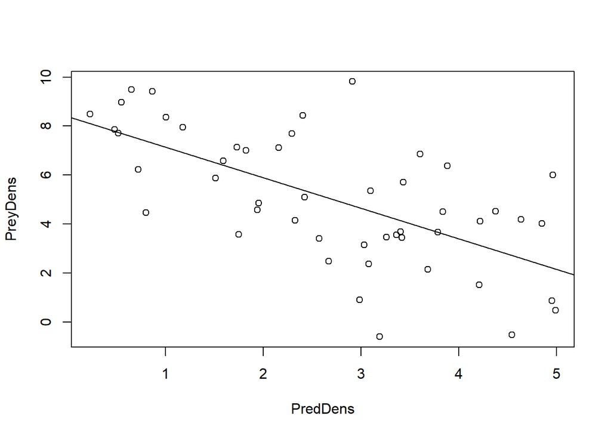

## Dataset #4

For each 1 prey/ha increase in prey density, we observed a 0.37 pup (± 0.17; ± 95% C.I.) increase in coyote litter size (p = 5.75e-05; r<sup>2</sup> = 0.15).

**Violates assumption of normality**

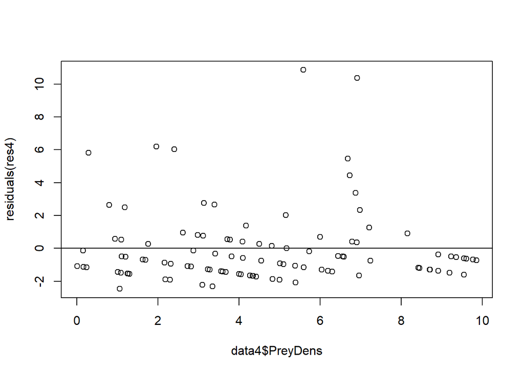

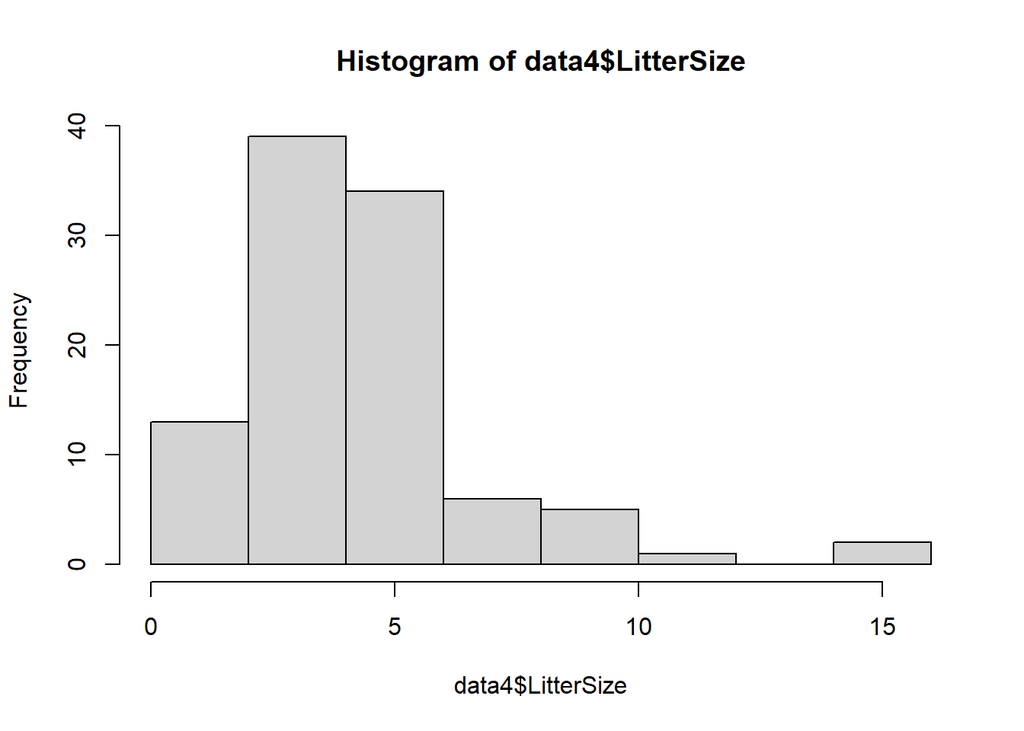

## Dataset #5

**Though it is a non-significant relationship**, for each 1 road/km<sup>2</sup> increase in road density, we observed a 0.0011 percent (± 0.17; ± 95% C.I.) decrease in probability of habitat use by wolves (p = 0.738; r<sup>2</sup> = 0.0012).

**Violates assumption of linearity**

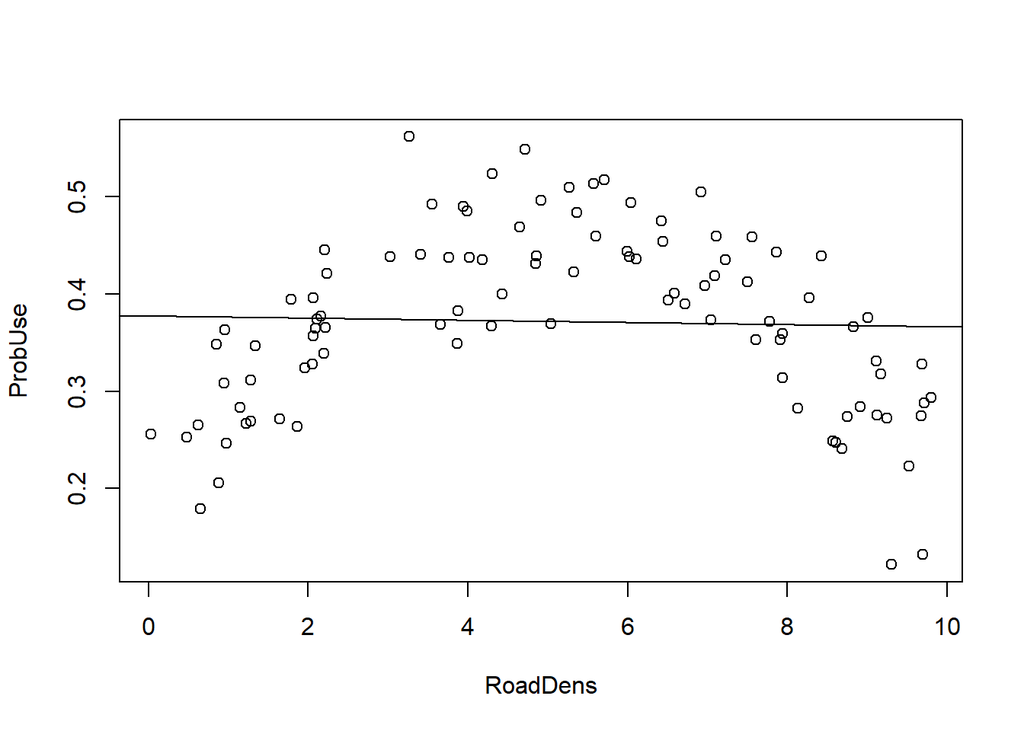